# Section 2: Mapping Occurrence Data with ggplot2

### ii) Adding the Mapping Component

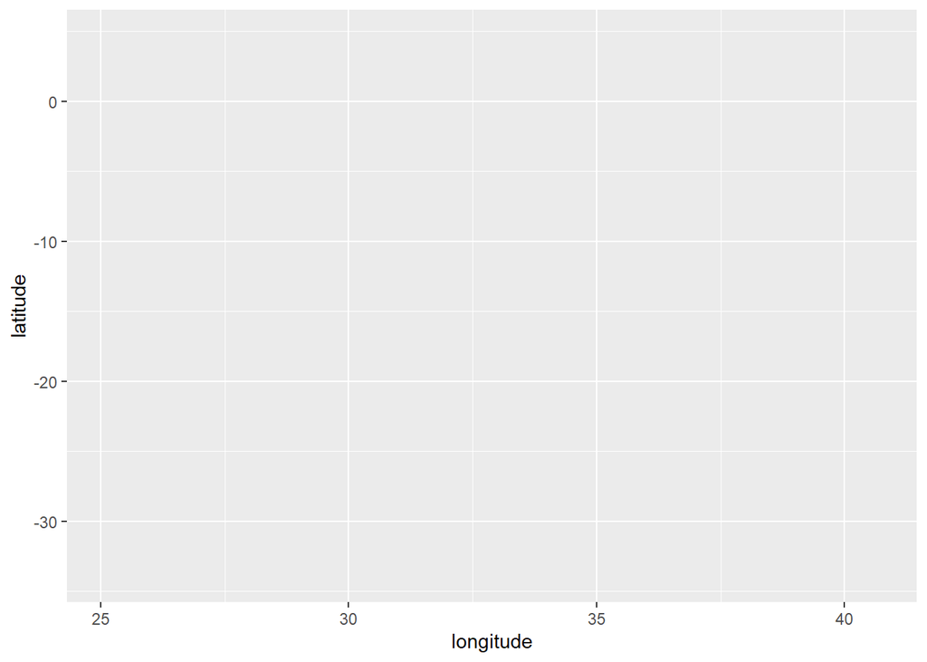

```r
# Base function + define mapping
ggplot(data = data, aes(x = longitude, y = latitude))
```

### iii) Adding the Occurrence Points

Great! Now we have an area to plot the latitude and longitude associated with each of the African Peach Moth observations. To add points to this graph, we will add on `geom_point` to the existing code. Note that adding this layer requires a “`+`”:

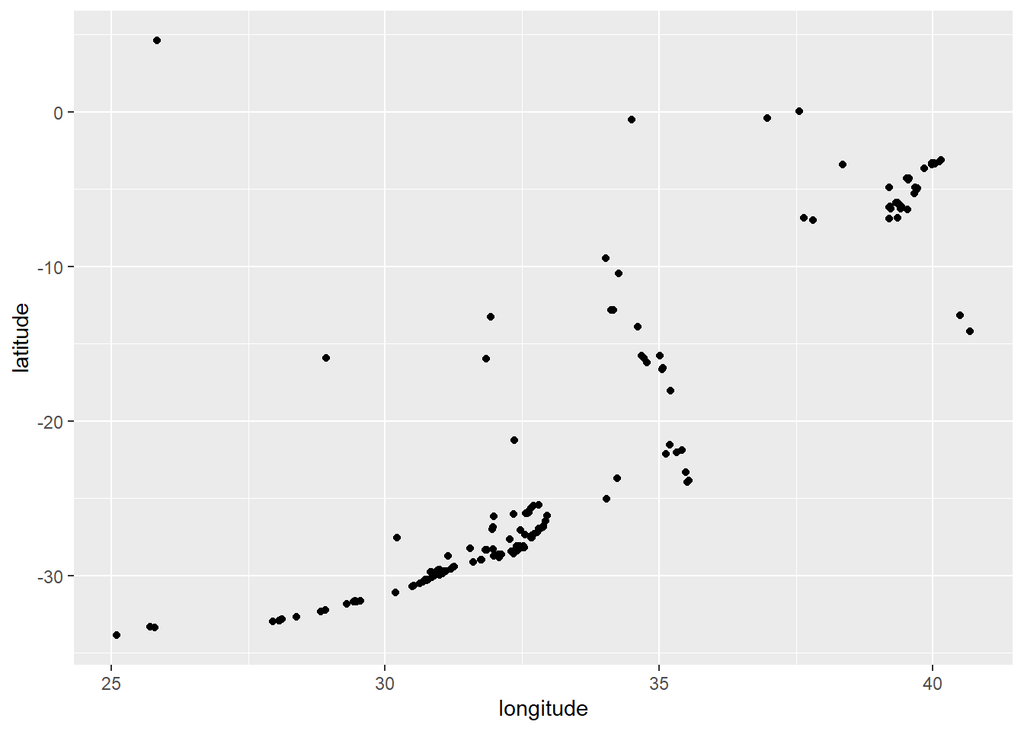

```r
# Base function + define mapping
ggplot(data = data, aes(x = longitude, y = latitude)) +
  # Add occurrence points
  geom_point()
```

**Note:** There is an alternate route to take when plotting the occurrences. Rather than having the data be passed through `ggplot()`, we can have it inside `geom_point()`. The code for that case would look like this:

```r
# Base function + define mapping
ggplot() +
  # Add occurrence points
  geom_point(data = data, aes(x = longitude, y = latitude))
```

The benefit to this is it groups our data to the function that plots the occurrences, as opposed to the base plotting function. Either way works, as you can see, but if we were to plot multiple and different data sets on the map then clustering each set to their respective `geom_` would make the code a little more organized.

### iv) Adding Country and Province Boundaries

So we have our occurrences on the map… but it is hard to tell where in the world they are, isn’t it? To solve this, we will pull out some world map data that is provided by `ggplot2` through a function called `map_data`:

```r
# Get world map boundaries
world_map <- ggplot2::map_data("world")
```

Of course, you might wonder what this data even looks like. And to that I present this visualization of that data we just gathered:

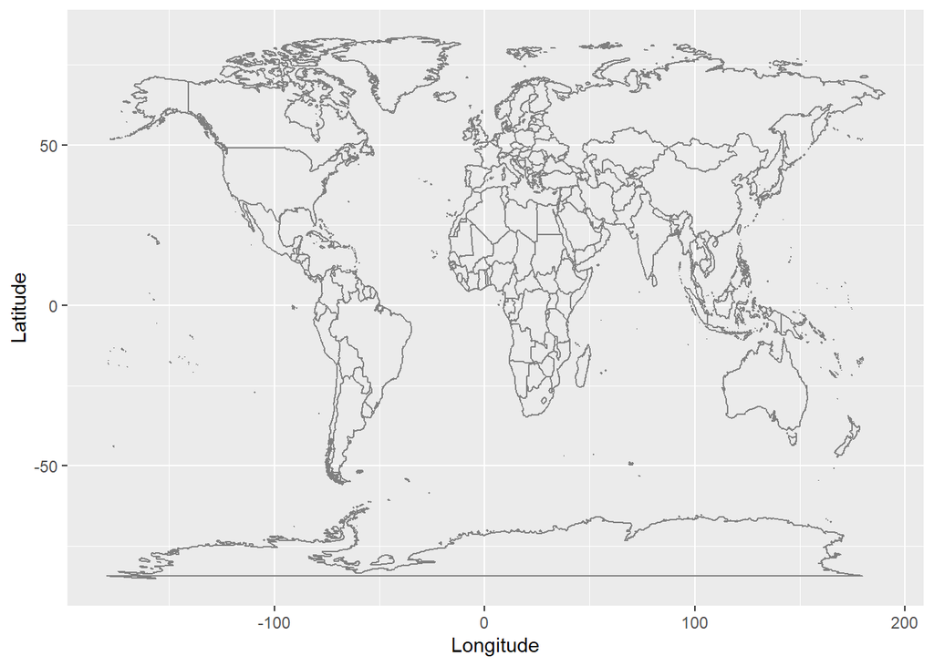

Now that that is settled, we can add boundaries to our moth map. This is done by adding `borders("world")` to the code. But note that we will be adding it before `geom_point()`. This is so that the borders layer is *under* the occurrence points layer:

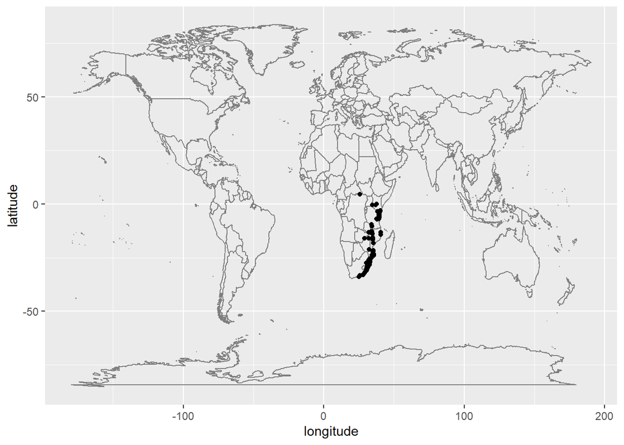

```r
# Base function + define mapping
ggplot(data = data, aes(x = longitude, y = latitude)) +
  # Add world boundaries
  borders("world") +
  # Add occurrence points
  geom_point()
```

### v) Adjusting Axis Limits

It would be beneficial to us and our peers if the observation points were easier to see, since those are what we are interested in after all. We can make the limits of the latitude and longitude axes hone in to where the observations are plotted by determining what the maximum and minimum values for each coordinate are. To do this, we will use `max()` and `min()` to find the outermost coordinates. Those values will then be used to construct a box around all the observations, to which we will add a buffer so that the plot does not cut off abruptly at those maximums and minimums. For the buffer, let us add 5 degrees to each maximum side of the box and subtract 5 degrees to each minimum:

```r
# Find northern-most latitude (this will be the top of our box)
top <- max(data$latitude) + 5

# Find southern-most latitude (bottom of box)
bottom <- min(data$latitude) - 5

# Find eastern-most longitude (right side of box)
right <- max(data$longitude) + 5

# Find western-most longitude (left side of box)
left <- min(data$longitude) - 5
```

Note that southern and western coordinates here are represented by negative values. This differs from what might be more commonly associated with an image of a globe, where the hemispheres are differentiated by “N”, “S”, “E”, or “W” while the degrees from the equator / prime meridian remain positive. Viewing the values we attained above, we would see the following:

```
##      north     south     east    west
## 1 9.619151 -38.86877 45.67643 20.0913
```

And plotting this bounding box on the map prior to cropping will show:

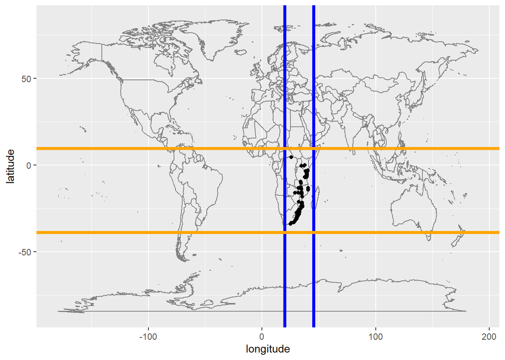

Now that that is taken care of, we can adjust the axes by adding our limits to arguments in `coord_fixed()`. :

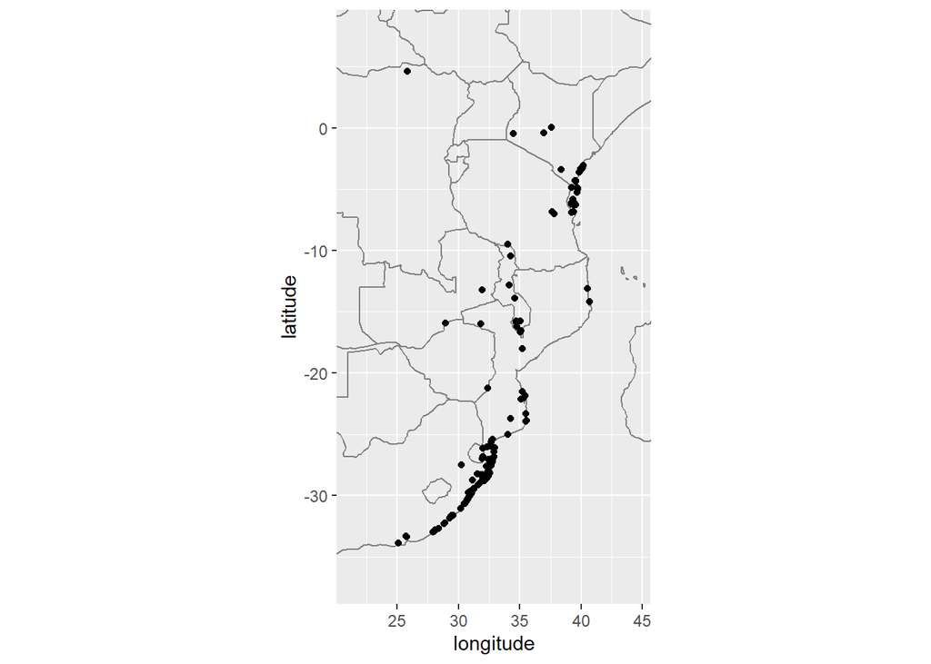

```r
# Base function + define mapping
ggplot(data = data, aes(x = longitude, y = latitude)) +
  # Add world boundaries
  borders("world") +
  # Add occurrence points
  geom_point() +
  # Specify axes limits
  coord_fixed(xlim = c(left, right),
              ylim = c(bottom, top),
              expand = F)
```

### vi) Making it Look Pretty

Wonderful! Now that we have a good foundation of a map, we can make it look a little jazzier. Of course, you could go down an entire rabbit hole of customizations and find yourself checking the time two hours later only to ask “At what cost?”. I am sure you would then look at your map and think about how glorious it is and think all that time was not wasted (or not… depending on your styling choices). Feel free to do some exploration, but here I will present some modifications to the following:

- *Axis labels*: If we were presenting this or adding it to a scientific paper, it would be a good idea to make sure grammar and capitalization of the content is reviewed to have that professional and publication-ready look. Changing the axis labels can be done with `xlab()` and `ylab()`, but here we will compound it under one function (`labs`) that also takes care of our title.
- *Theme*: Adding a `theme_` component will change the overall look of the plot. Mostly the background and grid lines in this case, but in other types of plots there may be changes to the design and colors as well.
- *Occurrence points*: We can change the color and size of our points on the map. It is also possible to change the points into other shapes, but I think I like to keep them as dots for this map.
- *Title*: If you handed this map by itself to someone and left them alone, they might want to know what they are looking at. Of course, this is solved by adding a title. But I am sure you knew that. Below you will notice that the title has some additional code to it compared to the axes labels — `bquote()`, `paste()`, and `bold()` / `bolditalic()`. If our title was just “Occurrence Map of the African Peach Moth”, then the extra code is not needed and we can follow the format used for the axes (`title = " "`). However, since species names are typically italicized we will want to represent it that way in our title.
  - **`bquote()`:** This function will evaluate font specifications, which in our case is making certain words bold and/or italic.
  - **`paste()`:** Takes different “strips” (also called “strings”) of characters and puts them together. Here we have a string with “Occurrence Map of” and another with ” Egybolis vaillantina”. The function will take those two and turn it into “Occurrence Map of Egybolis vaillantina”.
  - **`bold()` / `bolditalic()`:** These are functions that… well make characters bold and/or italicized.

What do these look like in action? We can take a look:

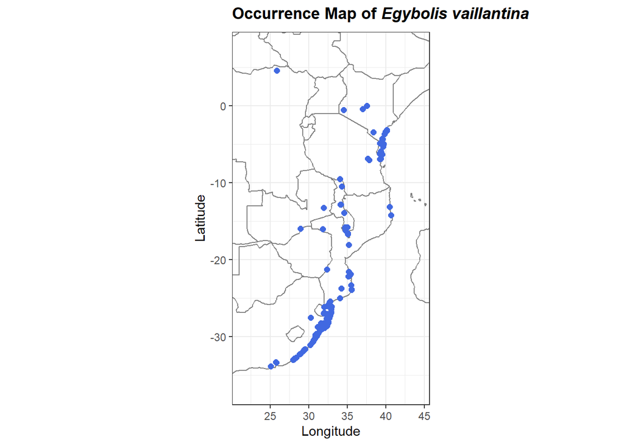

```r
# Base function + define mapping
ggplot(data = data, aes(x = longitude, y = latitude)) +
  # Add world boundaries
  borders("world") +
  # Add occurrence points
  geom_point(color = "royalblue",
             size = 2) +
  # Specify axes limits
  coord_fixed(xlim = c(left, right),
              ylim = c(bottom, top),
              expand = F) +
  # Capitalize axis labels and add a title
  labs(title = bquote(paste(bold("Occurrence Map of"),
                            bolditalic(" Egybolis vaillantina"))),
       x = "Longitude",
       y = "Latitude") +
  # Change theme
  theme_bw()
```

Yay! We have a reasonably nice-looking plot of our occurrence points.

### vii) Saving the Map

We did a lot of work to build that map! Now if we wanted to export it to presentations and documents, we should save it to our output folder. The `ggplot2` package has a function to do just that, called `ggsave()`. We will need to store our map in an object first, which we will call `gg_map`:

```r
# Store our map in an object
gg_map <- ggplot(data = data, aes(x = longitude, y = latitude)) +
  borders("world") +
  geom_point(color = "royalblue",
             size = 2) +
  coord_fixed(xlim = c(left, right),
              ylim = c(bottom, top),
              expand = F) +
  labs(title = bquote(paste(bold("Occurrence Map of"),
                            bolditalic(" Egybolis vaillantina"))),
       x = "Longitude",
       y = "Latitude") +
  theme_bw()

# Save our map
ggsave(filename = "output/egybolis_occurrence_map.png",
       plot = gg_map,
       width = 15,
       height = 25,
       units = "cm")
```

It is possible to save the map under certain dimensions to fit your needs, but make sure the ratios roughly follow that of the map (e.g. saving this map under a longer width than height will stretch it horizontally). I like to use centimeters as the image units because it is easier to visualize how large the outcome would be, but feel free to use pixels or inches.

Practicing good file management and naming conventions is important for many reasons, one of which being that it makes it easier to find your files in the first place. Here I chose to name the map as “egybolis_occurrence_map.png” which I think is something most people (or me in the distant future!) will be able to decipher if they were to go through my work. The prefix to that, “output/…”, places that file in the output folder since this is a product of our manipulations with the data. There are many different ways to organize your files, so do what works best for you!

## Additional Resources

- Best practices for file management: [MIT Communication Lab | File Structure](https://mitcommlab.mit.edu/broad/commkit/file-structure/)
- The `ggplot2` package has a lot of customization settings and visualizations other than a map. Learn more about it here: [Introduction to ggplot2](https://ggplot2.tidyverse.org/articles/ggplot2.html)
- R has a sea of color options. You can even make your own! Check out this site: [Colors in R](https://r-charts.com/colors/)
- If you are unsure about the accuracy of your map, you can always check the map provided on GBIF for your species. Searching up the species of your choice should give you a visual map of all the occurrences (before any data processing) alongside other information on the organism.

For questions, comments, or concerns (or even tattoo design requests) please email tmcruz@arizona.edu.